# Part I - (Prosper Loan Data Exploration)

#### LP_CustomerPrincipalPayments, Employment Status, and loan status

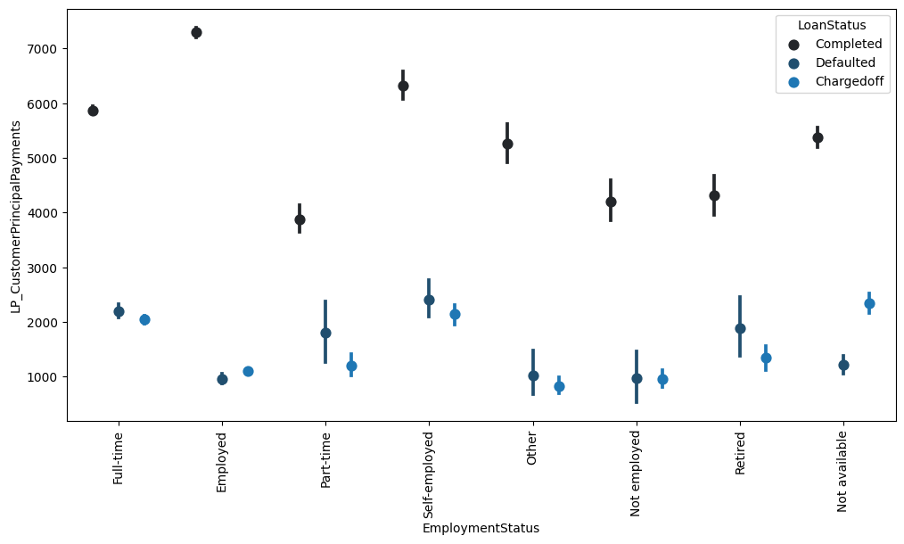

```python
fig, ax = plt.subplots(nrows=1, figsize=(12,6))
sb.pointplot(data=prosper_loan_sub[prosper_loan_sub['CreditScoreAverage']>=400], x='EmploymentStatus',
             y='LP_CustomerPrincipalPayments', hue='LoanStatus',
             dodge=0.5, join=False, ax=ax, order=y_order, color=b_color)
plt.xticks(rotation=90);
```

#### Employment Status, Recommendations and loan status

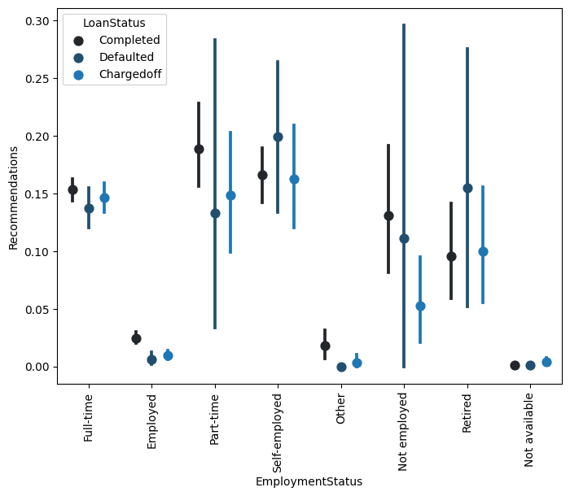

```python
fig, ax = plt.subplots(nrows=1, figsize=(8,6))
sb.pointplot(x='EmploymentStatus', y='Recommendations', data=prosper_loan_sub,
             hue='LoanStatus', ax=ax, join=False, dodge=0.5, order=y_order, color=b_color)
plt.xticks(rotation=90);
```

#### Employment Status, Listing Category and loan status

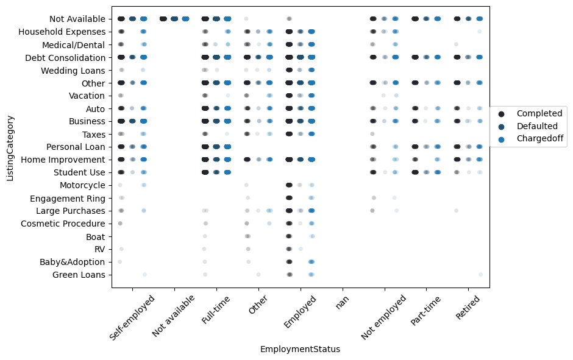

```python
fig, ax = plt.subplots(nrows=1, figsize=(8, 6))
sb.stripplot(data=prosper_loan_sub, y='ListingCategory', x='EmploymentStatus',
             hue='LoanStatus', jitter=True, ax=ax, dodge= 0.7, alpha=1/8, color = b_color)
plt.xticks(rotation=45)
plt.legend(loc=(1,0.5));
```

The data reveals an intriguing observation regarding individuals who choose "Not available" as their employment status. These borrowers also tend to select "Not available" as the reason for their loans. Additionally, they exhibit nearly equal chances of loan completion and default, indicating a lack of discernible pattern based on the given information.

On the other hand, individuals who are fully employed display a diverse range of loan purposes. Some of these borrowers have almost equal chances of being charged off or defaulted as they do of being completed. This indicates that employment status alone may not be the sole determining factor for loan outcomes, and other variables may play a significant role in influencing the likelihood of loan completion or default in this particular group.

### Talk about some of the relationships you observed in this part of the investigation. Were there features that strengthened each other in terms of looking at your feature(s) of interest?

In this section, a deeper investigation was conducted to explore the relationship between employment status and loan status, considering the interaction of other variables of interest. By factoring in additional variables, we aimed to gain a more comprehensive understanding of how employment status impacts loan outcomes and whether other factors play a role in influencing this relationship. The analysis aimed to uncover any patterns or trends that may have been overlooked when examining the variables in isolation, leading to a more robust assessment of the relationship between employment status and loan status.

### Were there any interesting or surprising interactions between features?

Indeed, the most surprising and notable observation from the investigation is the strong correlation between individuals who select "Not Available" as their employment status and those who also choose "Not Available" for their loan reason/purpose. This interesting pattern suggests a potential relationship between undisclosed or missing employment information and the reason behind seeking a loan. This finding may prompt further exploration to understand the underlying reasons why some borrowers choose to provide limited information about their employment status and loan purpose, and how this decision might influence loan outcomes. It highlights the importance of delving deeper into such data patterns to uncover potential insights and possible implications for lending practices and risk assessment.

## Conclusions

This dataset proved to be intriguing, challenging, and somewhat perplexing, as there were no directly evident or distinct features related to my main variable of interest. However, it revealed numerous implicit relationships worth exploring.

During the exploratory phase, I initially anticipated that two features, namely `Employment Status` and `Verifiable income sources`, would have the highest predictive potential for my main variable. However, after scrutinizing the distribution of `Verifiable income source` concerning the main variable, I opted to exclude it from further analysis.

These conditions provide valuable insights into the characteristics that are more likely to lead to loan completion, despite the dataset's initial complexity and lack of apparent relationships.

```python
!jupyter nbconvert Part_1.ipynb --to html --no-input --no-prompt
```

```
[NbConvertApp] Converting notebook Part_1.ipynb to html
[NbConvertApp] WARNING | Alternative text is missing on 34 image(s).
[NbConvertApp] Writing 1859880 bytes to Part_1.html
```